# R para los de Letras

J. M. Fradejas

2024.12.18

[figure not shown]

# Introducción

Este documento contiene los instrucciones para el taller *R para los de Letras* ofrecido por la [Facultad de Filosofía y Letras](https://fyl.uva.es/) de la [Universidad de Valladolid](https://www.uva.es/export/sites/uva/).

El objetivo de este taller es introducirse en el uso de R como herramienta para analizar datos textuales, pero ofrece información valiosa para cualquiera que quiera introducirse en R.

Este taller está dirigido a principiantes con el objetivo de mostrar cómo configurar una sesión de R en RStudio, cómo configurar proyectos en R y cómo realizar operaciones básicas usando R.

## Los objetivos de este taller

Los objetivos de este taller son:

- Instalar R
- Cómo moverse en R y RStudio
- Cómo crear y trabajar con proyectos en R
- Dónde buscar ayuda y aprender más acerca de R
- Comprender los principios básicos al trabajar con datos: cargarlos, guardarlos, trabajar con tablas, crear un gráfico sencillo

## Audiencia

Este taller es para principiantes. No es necesario saber nada de R, ni de lenguas de programación.

Se ruega que todos los participantes traigan su propio ordenador con el software ya instalado. Al usar su propio ordenador, nos aseguramos de que tras el taller podrán continuar usando lo que se ha aprendido una vez haya finalizado el taller.

## Instalar R y RStudio

Durante el taller, se usará RSudio. RStudio es un exelente manera de manejar el lenguaje de programación R. Para usarlo, debes intalar tanto R como RStudio.

Por favor, sigue las instrucciones que hay a continuación para instalar R y RStudio y hazlo antes de acudir al taller. Asegúrate de que el software funciona que debe una vez instalado. ¡Te diremos cómo hacerlo!

- Tiene un ordenador con Windows?
  - Descarga R. [Este enlace lo desacargará](https://cran.rediris.es/bin/windows/base/R-4.4.2-win.exe)
  - Ejecuta el fichero `.exe` que acabas de descargar (se encuentra en la carpeta `Descargas`), y sigue sus instrucciones
  - Ahora descarga RStudio. [Este enlace lo descargará](https://download1.rstudio.org/electron/windows/RStudio-2024.12.0-467.exe)
  - Cuando se haya descargado, ejecuta el fichero `.exe` que acaba de bajar (estará en la carpeta `Descargas`), y sigue las instrucciones
  - Una vez que se haya finalizado la instalación, abre Rstudio y asegúrate de que funciona y de que no haya mensajes de error.
- Tienes un Mac?
  - Desargar R. Si tienes un ordenador con los chips M1/M2/M3/M4 [usa este enlace](https://cran.rediris.es/bin/macosx/big-sur-arm64/base/R-4.4.2-arm64.pkg), pero si tu ordenador tiene un procesador Intel entonces [usa este otro enlace](https://cran.rediris.es/bin/macosx/big-sur-x86_64/base/R-4.4.2-x86_64.pkg)
  - Ejecuta el fichero `.pkg` que acabas de ejecutar (estará en la carpeta `Descargas`), y sigue las instrucciones
  - Ahora descarga RStudio. [Este enlace lo descargará](https://download1.rstudio.org/electron/macos/RStudio-2024.12.0-467.dmg)
  - Cuando se haya descargado, ejecuta el fichero `.dmg` que acaba de bajar (estará en la carpeta `Descargas`), y sigue las instrucciones
  - Una vez que se haya finalizado la instalación, abre Rstudio y asegúrate de que funciona y de que no haya mensajes de error.

Cuando arranques RStudio, verás que se parece a esta imagen (las tres primeras líneas serán diferentes, pues dependen del tipo de ordenador y de la versión de R):

[figure not shown]

# R y RStudio. Lo básico

RStudio is an IDE - Integrated Development Environment. The interface provides easy access to R. The advantage of this application is that R programs and files as well as a project directory can be managed easily. The environment is capable of editing and running program code, viewing outputs and rendering graphics. Furthermore, it is possible to view variables and data objects of an R-script directly in the interface.

## RStudio: Paneles

The GUI - Graphical User Interface - that RStudio provides divides the screen into four areas that are called **panes**:

1. File editor
2. Environment variables
3. R console
4. Management panes (File browser, plots, help display and R packages).

The two most important are the R console (bottom left) and the File editor (or Script in the top left). The Environment variables and Management panes are on the right of the screen and they have several tabs:

- **Environment** (top): Lists all currently defined objects and data sets
- **History** (top): Lists all commands recently used or associated with a project
- **Plots** (bottom): Graphical output goes here
- **Help** (bottom): Find help for R packages and functions. Don’t forget you can type `?` before a function name in the console to get info in the Help section.
- **Files** (bottom): Shows the files available to you in your working directory

### R Console (bottom left pane)

The console pane allows you to quickly and immediately execute R code. You can experiment with functions here, or quickly print data for viewing.

Type next to the `>` and press `Enter` to execute.

**EXERCISE TIME!**

1. You can use R like a calculator. Try typing `2+8` into the **R console**, as is the following image.

[figure not shown]

**Answer**

```
## [1] 10
```

Here, the plus sign is the **operator**. Operators are symbols that represent some sort of action. However, R is, of course, much more than a simple calculator. To use R more fully, we need to understand **objects**, **functions**, and **indexing** (the number between square brackets)- which you will learn about as we go.

For now, think of *objects as nouns* and *functions as verbs*.

## Script Editor pane (top left pane)

The Editor pane only opens if prompted. It is very flexible since it allows you to go back and forth, highlights the various components of an expression in colors, allows you to save a script to reuse it and correct errors without having to rewrite everything. The way to open it is very simple click on `File`

[figure not shown]

Click on `New File` and then on `R Script` as shown below.

[figure not shown]

This `R Script` will be the file in which you do all your work.

## Running commands from a script

In contrast to the R console, which quickly runs code, the Script Editor (in the top left) does not automatically execute code. To run code from a script, insert your cursor on a line with a command, and press `CTRL/CMD+Enter`.

Or highlight some code to only run certain sections of the command, then press `CTRL/CMD+Enter` to run.

Alternatively, use the `Run` button at the top of the pane to execute the current line or selection (see below).

[figure not shown]

# Getting started with R

This section introduces some basic concepts and procedures that help optimize your workflow in R.

## Setting up an R session

At the beginning of a session, it is common practice to define some basic parameters. This is not required or even necessary, but it may just help further down the line. This session preparation may include specifying options. In the present case, we

- want R to show numbers as numbers up to 100 decimal points (and not show them in mathematical notation (in mathematical notation, 0.007 would be represented as 0.7e<sup>-3</sup>))
- want R to show maximally 100 results (otherwise, it can happen that R prints out pages-after-pages of some numbers).

Again, the session preparation is not required or necessary but it can help avoid errors.

**WARNING**  
Whenever you see a grey box as the one below, select and cut the text within it, and the paste it into RStudio editor pane.

```r
# set options
options(stringsAsFactors = F)
options(scipen = 100)
options(max.print=100)
```

## Packages

When using R, most of the functions are not loaded or even installing automatically. Instead, most functions are in contained in what are called **packages**.

The bare-bone R comes with about 30 packages (“base R”). There are over 10,000 user-contributed packages; you can discover these packages online. A prevalent collection of packages is the `tidyverse`, which includes `ggplot2`, a package for making graphics.

You must load the package in any new R session where you want to use that package. Below I show what you need to type when you want to install the `tidyverse`, the `tidytext`, the `quanteda`, and the `stopwords` packages (which are the packages that we will need in this workshop).

```r
install.packages("tidyverse")
install.packages("tidytext")
install.packages("quanteda")
install.packages("stopwords")
```

To load these packages, use the `library` function which takes the package name as its main argument.

```r
library(tidyverse)
library(tidytext)
library(quanteda)
library(stopwords)
```

The session preparation section of your script file will thus also state which packages a script relies on.

[figure not shown]

The lines starting with *#* and printed in green are comments. They are very useful to remind you what a line or chunk of code does.

## Getting help

When working with R, you will encounter issues and face challenges. A very good thing about R is that it provides various ways to get help or find information about the issues you face.

### Finding help within R

To get help regrading what functions a package contains, which arguments a function takes or to get information about how to use a function, you can use the `help` function or you can simply type a `?` before the package or or function. I you run any of these two instruccions in the Console pane, the Help tab on the botton right pane will show the answer.

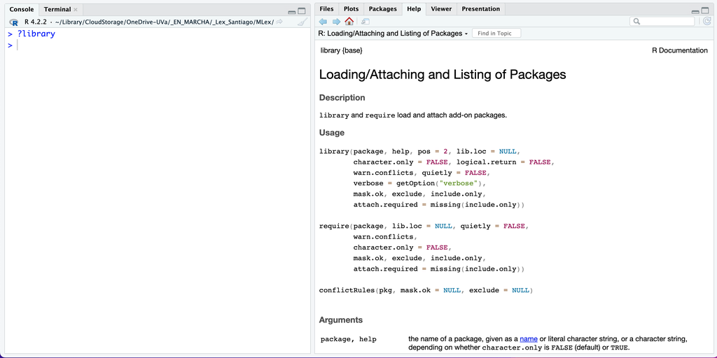

```r
help(library)
?library
```

There are also other “official” help resources from R/RStudio.

- Read official package documentation, see vignettes, e.g., Tidyverse https://cran.r-project.org/package=tidyverse
- Use the RStudio Cheat Sheets at https://www.rstudio.com/resources/cheatsheets/
- Check out the keyboard shortcuts `Help` under `Tools` in RStudio for some good tips

### Finding help online

One great thing about R is that you can very often find an answer to your question online. [R-bloggers](https://www.r-bloggers.com/) and [Stackoverflow](https://stackoverflow.com/questions/tagged/r) are great places to find tips and help.

[figure not shown]

**NOTE**  
This R Notebook is based on some [Ladal](https://ladal.edu.au/tutorials.html), [Programming Historian](https://programminghistorian.org/en/lessons/basic-text-processing-in-r) and [CuentaPalabras](http://www.aic.uva.es/cuentapalabras/) tutorials.  
For linguistics I highly recommend Ladal tutorials.

PID2020-112621GB-I00/AEI/10.13039/501100011033